# 予測問題

機械学習

[川田恵介](https://github.com/tetokawata/TargetML)

keisukekawata@iss.u-tokyo.ac.jp

東京大学

2025-09-16

# 予測問題

## 目標

- 「データをモデルに要約する」をイメージとして掴む
  - 研究者主導アプローチの代表格である、OLSを紹介
- 正しい予測モデル評価法を学ぶ
  - 複雑なモデルが必ずしも高性能ではないことを確認

## ロールプレイ

- 大手不動産会社にて、中古マンションの買取査定支援”AI”を開発しろ、と命じられた
  - 重要な情報は、当該物件の市場価格
    - 価格は、マンションの持つさまざまな属性(広さ、立地、築年数等)によって異なるため、予測困難
  - これらの属性から、取引価格を予測するモデルを構築したい

## 予測

- 日常的な予測: 自身が経験した/見聞きした事例の傾向から、なんとなく予想する
  - 港区の広い物件は、高い価格である傾向等
- データに基づく予測: 大規模なデータ上での傾向を要約し、予測モデル(“AI”)を推定
  - 国土交通省が提供する [不動産情報ライブラリ](https://www.reinfolib.mlit.go.jp/) からデータを入手

## データ

| Price | Size | District | Tenure | Distance |
| --- | --- | --- | --- | --- |
| 94 | 40 | 千代田区 | 3 | 3 |
| 100 | 65 | 千代田区 | 12 | 4 |
| 130 | 65 | 千代田区 | 21 | 4 |
| 98 | 65 | 千代田区 | 16 | 4 |
| 58 | 40 | 千代田区 | 7 | 3 |

- Size $=$ 部屋の広さ、Tenure $=$ 築年数、Distance $=$ 駅からの距離(分)

# 予測モデル

## 単純な予測モデル

- とりあえず、部屋の広さ(Size)のみから取引価格を予測するモデルを推定する
  - 予測モデル $=$ $f(Size)$
    - Sizeを入力すれば、予測取引価格を自動計算してくれる

## 部屋の広さと取引価格の傾向

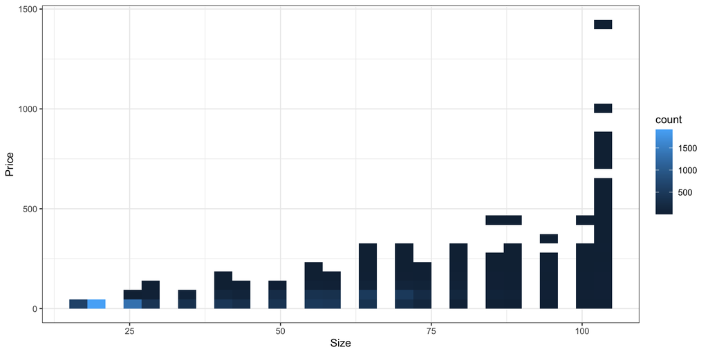

## 情報の要約

- 全く同じSizeでも、取引価格は大きく異なる
  - Size以外の要因が取引価格を左右
    - 最大値を予測価格とすると、他の要因が上振れた事例から予測しており、一般に不適切
      - 例: 男性の予測値
        - $=$ 大谷翔平選手….?
- 代表的な方法は平均値

## 部屋の広さと平均取引価格の傾向

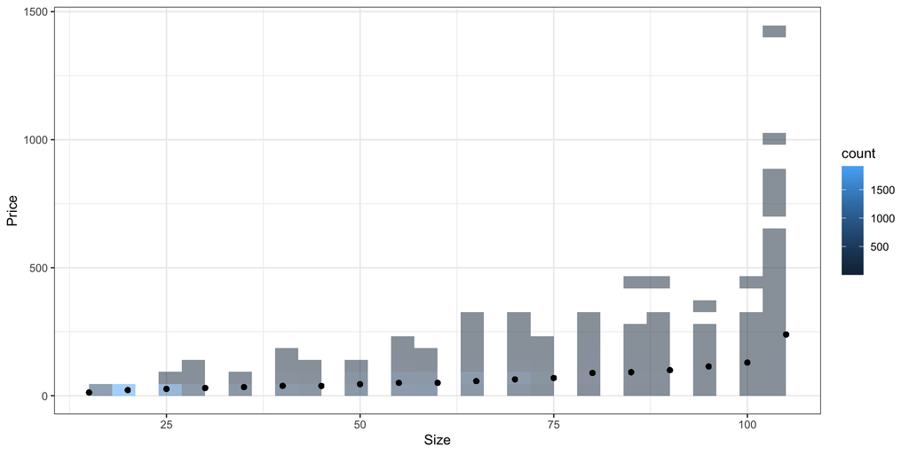

## 部屋の広さと平均取引価格の傾向

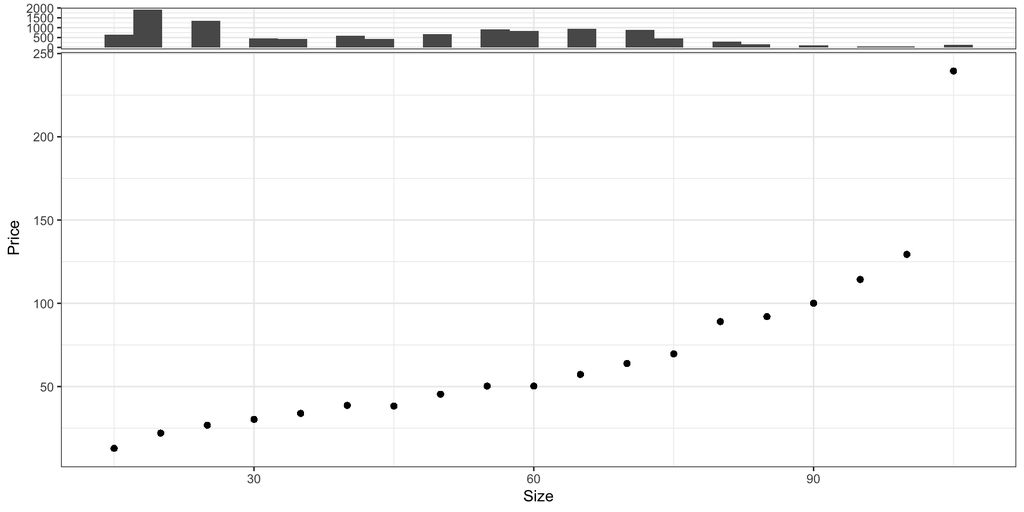

## 小規模事例の平均

- 平均値の計算に用いる事例が少なければ、観察できない要因の上振れ/下振れの影響を受けやすい
  - 岩手県水沢市出身31歳男性の事例は、大谷翔平選手のみ
  - 岩手県水沢市出身31歳男性の所得の平均値
    - $\simeq$ 大谷翔平選手の所得….?

## モデル化

- データの特徴を”大雑把に”捉える
- 代表例は線型モデル
  $$Y\simeq \beta_0 + \beta_1X_1+..$$
  - 極力データに適合するように、$\beta$ の値を選ぶ

## 例

```r
lm(Price ~ Size, Data)
```

```
Call:
lm(formula = Price ~ Size, data = Data)

Coefficients:
(Intercept)         Size
     -6.463        1.133
```

- Size $=50$ の物件の予測取引価格は、
  $$-6.463+1.133\times \underbrace{Size}_{=50}\simeq 50.2$$

## 例

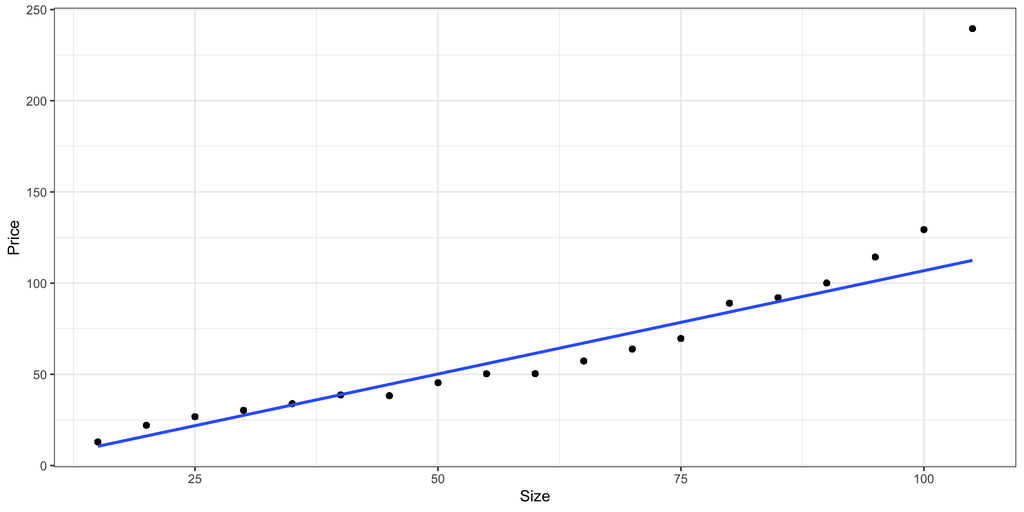

## 曲線モデル

- 直線以外を当てはめることも容易
- $$Y\simeq \beta_0 + \beta_1X_1+\beta_2\underbrace{X_2}_{X_1^2}$$

## 例

```r
lm(Price ~ Size + I(Size^2), Data)
```

```
Call:
lm(formula = Price ~ Size + I(Size^2), data = Data)

Coefficients:
(Intercept)         Size    I(Size^2)
   36.94330     -1.09684      0.02256
```

## 例

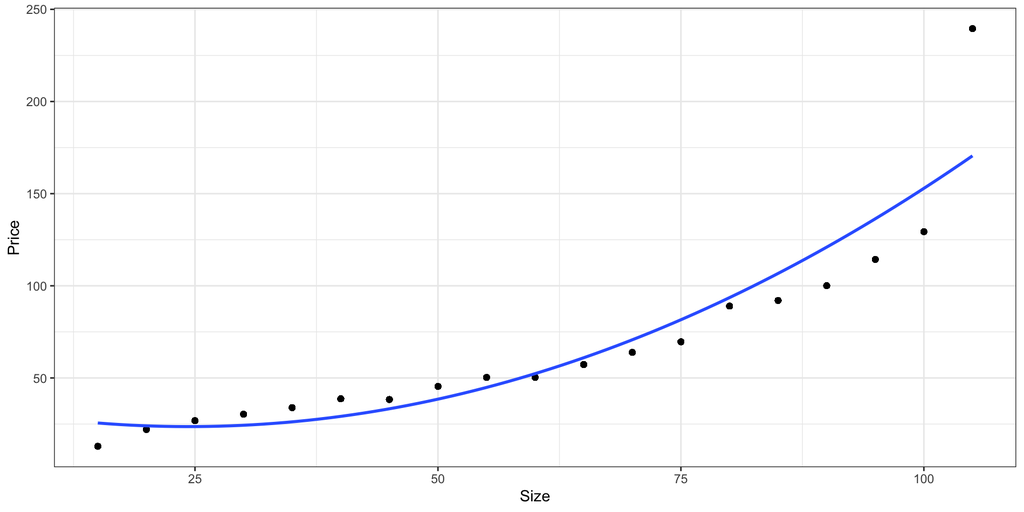

## 重回帰

- 複数の属性も容易に導入できる
  - 平均値の場合、事例数がより少なくなり、非現実的
- 例
  $$Price\simeq$$
  $$\beta_0 + \beta_1Size+\beta_2Tenure+... + \beta_3千代田+..$$
  - 千代田: 千代田区であれば1、それ以外であれば0

## 例

```r
lm(Price ~ Size + Tenure + District, Data)
```

```
Call:
lm(formula = Price ~ Size + Tenure + District, data = Data)

Coefficients:
     (Intercept)              Size            Tenure    District中央区
          2.6467            1.2127           -0.6799           11.1456
  District中野区      District北区  District千代田区    District台東区
          3.7414           -9.9308           33.2732           -0.1924
  District品川区    District大田区    District文京区    District新宿区
          8.1725           -4.4987            8.0578           11.4954
  District杉並区    District板橋区  District江戸川区    District江東区
          2.8550          -12.4476          -27.5717           -7.2599
  District渋谷区      District港区    District目黒区    District練馬区
         26.5507           43.4248           15.3891          -12.1884
  District荒川区    District葛飾区    District豊島区    District足立区
        -15.5613          -22.1682            3.6266          -22.6756
  District墨田区
         -5.1848
```

## Takeaway

- 研究者が指定した線型モデルに、大量の属性情報を集約する
  - OLSは、データに当てはまるようにモデルを推定する
  - 性能の良いモデルであれば、実務に実装できる

```
flowchart LR
  D[データ] --> |推定| M[予測モデル] --> |実装| S[実務]
```

# 予測モデルの性能評価

## 推定と評価

- 予測モデルは、どの程度機能するのか?
  - 実務上極めて重要
- 事後評価: 実際に実装し業務に活用しながら、確かめる
  - 予測に失敗した場合の被害が軽微な場合は活用可能

## 事後評価

1. 予測モデルを推定
2. 実際の事例に応用し、実際の価格と予測価格を新規に取集
3. 実際と予測価格の乖離を測定: 典型的には

$$(実際の価格 - 予測価格)^2$$

## 事前評価

- 実務に実装する前に、その予測精度を測定したい
- 課題は、
  - 予測の評価に用いるための、新規の事例が存在しない

## 不適切な事前評価

- 「モデルを推定した事例を、テストにも再利用」したくなるが、間違えた方法
  - 予測ではなく、“確認”であり、過度に高い評価になってしまう
- 有名な警句: 「Double dipping (２度漬け) には注意」

## 例: 自己啓発本的レトリック

```
flowchart LR
  A[データ <br> 大谷翔平は <br> オートミールを食べていた] --> |一般化| D[モデル/仮説 <br> オートミールを食べている人間は <br> 運動能力が高い]
  D -->|検証| A
```

## 例

- ２事例のみからなる(しょぼい)データから予測モデルを推定する

| 出身地Y | 所属大学X |
| --- | --- |
| 香川県 | 武蔵大学 |
| 大阪府 | 東京大学 |

- $f(武蔵大学)=香川県$ と予測モデルを推定
  - 直感的に予測性能は低い

## 例: 新しい事例によるテスト

| 所属大学X | 出身地Y | 予測値 |
| --- | --- | --- |
| 武蔵大学 | 東京都 | 香川県 |
| 武蔵大学 | 東京都 | 香川県 |
| 武蔵大学 | 東京都 | 香川県 |
| 武蔵大学 | 東京都 | 香川県 |
| 武蔵大学 | 千葉県 | 香川県 |

- まったく当てはまらないことがわかる

## 例: 同じ事例によるテスト

- 同じ事例に当てはめると

| 所属大学X | 出身地Y | 予測値 |
| --- | --- | --- |
| 武蔵大学 | 香川県 | 香川県 |

- 一見完璧に当てはまるが、予測ではなく、“確認”しているだけ

## 推奨される事前評価

- データを２分割 (訓練/テスト) にランダム分割する
  - 訓練: 予測モデルを推定する
  - テスト: 予測性能を評価する

## 実例

| Price | Size | District | OLS | Error: OLS |
| --- | --- | --- | --- | --- |
| 28.0 | 20 | 新宿区 | 55 | 729.00 |
| 150.0 | 75 | 文京区 | 51 | 9801.00 |
| 43.0 | 55 | 品川区 | 45 | 4.00 |
| 33.0 | 40 | 品川区 | 45 | 144.00 |
| 70.0 | 55 | 目黒区 | 45 | 625.00 |
| 30.0 | 25 | 目黒区 | 43 | 169.00 |
| 29.0 | 30 | 目黒区 | 43 | 196.00 |
| 48.0 | 60 | 豊島区 | 41 | 49.00 |
| 6.5 | 15 | 板橋区 | 21 | 210.25 |
| 30.0 | 60 | 足立区 | 31 | 1.00 |
| 24.0 | 80 | 葛飾区 | 29 | 25.00 |

## 実例

```r
set.seed(11)

Group = sample(1:2, nrow(Data), replace = TRUE) # データの分割

FitOLS = lm(
  Price ~ Tenure + District,
  Data,
  subset = Group == 1) # OLSモデルの推定

FitMean = lm(
  Price ~ 1,
  Data,
  subset = Group == 1) # 平均値の推定

mean((Data$Price - predict(FitOLS,Data))[Group == 2]^2) # OLSのテスト
```

```
[1] 1805.888
```

```r
mean((Data$Price - predict(FitMean,Data))[Group == 2]^2) # 平均値のテスト
```

```
[1] 2109.792
```

## 実例

- 平均値の方が、OLSよりも予測力が低い
  - 事例数が少なく、集団の傾向との乖離が大きい

## 不適切な事前評価

```
flowchart LR
  A[データ] --> |推定| D[予測モデル]
  D[予測モデル] -->|評価| A
```

## 適切な事前評価

```
flowchart LR
  A[データ] --> B[訓練データ] --> |推定| D[予測モデル]
  A[データ] --> C[テストデータ]
  D[予測モデル] -->|評価| C
```